# Session 4: Point Pattern Analysis I (Data Preprocessing)

# Introduction

Here I document the data preprocessing for this activity.

I want to give students real datasets that they can analyze, without having to go through all the data preprocessing, in particular converting shape files into `spatstat` objects, and so on.

Therefore, I will convert all files into objects that the students can readily use.

One data set is of businesses in Toronto. I will use the city boundaries and point data for businesses (including Paez Mart).

The shape file with the city boundaries is called `Toronto`.

# Data preprocessing

Clear workspace.

```r
rm(list = ls())
```

Next, load the libraries needed to do this:

```r
library(tidyverse)
library(spatstat)
library(spdep)
library(rgdal)
library(maptools)
#library(readxl)
#library(dplyr)
#library(ggplot2)
#library(tmap)
library(broom)
library(ggmap)
#library(readr)
```

I can now proceed to read the geospatial file.

For this example, I will use an ESRI shape file that contains the city boundary of Toronto. The command used for this is `rgdal::readOGR` (note that `package::function` indicates a function in the name package):

```r
Toronto <- readOGR(dsn = ".", layer = "Toronto")
```

This creates a `SpatialPolygonsDataFrame`, an R object used to store geographical information (in this example spatial polygons; other types of spatial data are points, lines, or pixels; more generally `Spatial*DataFrames`).

Next, I want to create an object window object (`owin`) used by `spatstat` to define regions for spatial point pattern analysis:

```r
Toronto.owin <- as(Toronto, "owin")
```

```r
Toronto <- tidy(Toronto, region = "ID")
#Rename id column
Toronto <- rename(Toronto, GTA06 = "id")
```

I have now a data frame that can be plotted in `ggmap`.

I will read the business datapoints that I want to use. They are already in `Fast_Food.RData`

```r
load("Fast_Food.RData")
```

Now convert the fast food points to a `ppp` object:

```r
Fast_Food <- Fast_Food %>% select(x = LONGITUDE, y = LATITUDE, Class = Class) %>%
  mutate(x = x + runif(nrow(Fast_Food), min = -0.005, max = 0.005),
         y = y + runif(nrow(Fast_Food), min = -0.005, max = 0.005))
Fast_Food.ppp <- as.ppp(Fast_Food, W = Toronto.owin)
```

```
371 points were rejected as lying outside the specified window
```

```r
Fast_Food.ppp <- as.ppp(Fast_Food.ppp) #To remove rejected points for good
```

Now extract, the coordinates and labels to create a dataframe with only the points inside the window:

```r
Fast_Food <- data.frame(Fast_Food.ppp$x, Fast_Food.ppp$y, Fast_Food.ppp$marks)
Fast_Food <- rename(Fast_Food, x = Fast_Food.ppp.x, y = Fast_Food.ppp.y, Class = Fast_Food.ppp.marks)
```

Next, extract Gasoline Service Stations (PRMSIC4 == 5541) for Toronto (CMACA == 535):

```r
Gas_Stands <- read_csv("Business Location File 2008.csv")
Gas_Stands <- Gas_Stands %>% filter(CMACA == 535 & PRMSIC4 == 5541)
Gas_Stands <- Gas_Stands %>% mutate(LONGITUDE = LONGITUDE + runif(nrow(Gas_Stands), min = -0.005, max = 0.005),
                                    LATITUDE = LATITUDE + runif(nrow(Gas_Stands), min = -0.005, max = 0.005))
```

Select variables:

```r
Gas_Stands <- select(Gas_Stands, x = LONGITUDE, y = LATITUDE)
```

Convert `Gas_Stands` to `ppp` object:

```r
Gas_Stands.ppp <- as.ppp(Gas_Stands, W = Toronto.owin)
```

```
471 points were rejected as lying outside the specified window
```

```r
Gas_Stands.ppp <- as.ppp(Gas_Stands.ppp)
```

Now extract, the coordinates and labels to create a dataframe with only the points inside the window:

```r
Gas_Stands <- data.frame(Gas_Stands.ppp$x, Gas_Stands.ppp$y)
Gas_Stands <- rename(Gas_Stands, x = Gas_Stands.ppp.x, y = Gas_Stands.ppp.y)
```

Create locations for “Paez Mart”:

```r
Paez_Mart <- gridcenters(Toronto.owin, nx = 40, ny = 20)
Paez_Mart <- data.frame(Paez_Mart)
```

Convert `Paez_Mart` to `ppp` object:

```r
Paez_Mart.ppp <- as.ppp(Paez_Mart, W = Toronto.owin)
```

```
405 points were rejected as lying outside the specified window
```

```r
Paez_Mart.ppp <- as.ppp(Paez_Mart.ppp)
```

Now extract, the coordinates and labels to create a dataframe with only the points inside the window:

```r
Paez_Mart <- data.frame(Paez_Mart.ppp$x, Paez_Mart.ppp$y)
Paez_Mart <- rename(Paez_Mart, x = Paez_Mart.ppp.x, y = Paez_Mart.ppp.y)
```

These dataframes can be plotted using `ggplot2`:

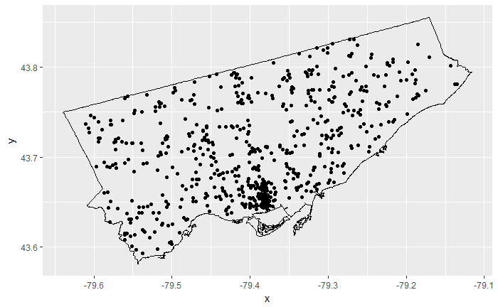

```r
ggplot() + geom_point(data = Fast_Food, aes(x = x, y = y)) +
    geom_polygon(data = Toronto, aes(x = long, y = lat, group = group), color = "black", fill = NA, alpha = 1, size = .3)
```

Create density maps:

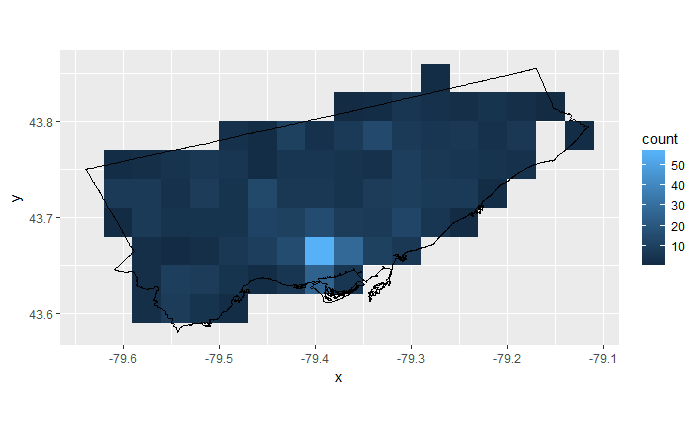

```r
ggplot() +
  geom_bin2d(data = Fast_Food,
             aes(x = x, y = y),
             binwidth = c(0.03, 0.03)) +
    geom_polygon(data = Toronto, aes(x = long, y = lat, group = group), color = "black", fill = NA, alpha = 1, size = .3) +
  coord_fixed()
```

Create density maps:

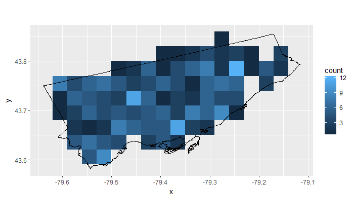

```r
ggplot() +
  geom_bin2d(data = Gas_Stands,
             aes(x = x, y = y),
             binwidth = c(0.03, 0.03)) +
    geom_polygon(data = Toronto, aes(x = long, y = lat, group = group), color = "black", fill = NA, alpha = 1, size = .3) +
  coord_fixed()
```

Create density maps:

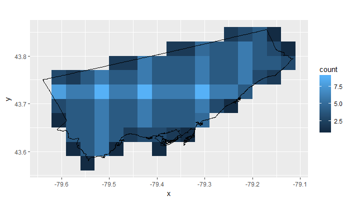

```r
ggplot() +
  geom_bin2d(data = Paez_Mart,
             aes(x = x, y = y),
             binwidth = c(0.03, 0.03)) +
    geom_polygon(data = Toronto, aes(x = long, y = lat, group = group), color = "black", fill = NA, alpha = 1, size = .3) +
  coord_fixed()
```

Summarize the `ppp` objects:

```r
summary(Paez_Mart.ppp)
```

```
Planar point pattern:  395 points
Average intensity 5573.561 points per square unit

Coordinates are given to 6 decimal places

Window: polygonal boundary
10 separate polygons (no holes)
            vertices        area relative.area
polygon 1       4185 7.05052e-02      9.95e-01
polygon 2        600 2.82935e-04      3.99e-03
polygon 3        193 2.64610e-05      3.73e-04
polygon 4         28 2.96067e-06      4.18e-05
polygon 5         52 1.59304e-05      2.25e-04
polygon 6         67 1.76751e-05      2.49e-04
polygon 7         41 9.31149e-06      1.31e-04
polygon 8         30 4.78946e-06      6.76e-05
polygon 9         36 3.77806e-06      5.33e-05
polygon 10         8 1.23483e-06      1.74e-05
enclosing rectangle: [-79.6393, -79.11547] x [43.58107, 43.85539] units
Window area = 0.0708703 square units
Fraction of frame area: 0.493
```

Now calculate the quadrat counts:

```r
q_count_ff <- quadratcount(Fast_Food.ppp, nx = 17, ny = 10)
quad_freq_ff <- table(q_count_ff)
q_count_gs <- quadratcount(Gas_Stands.ppp, nx = 17, ny = 10)
quad_freq_gs <- table(q_count_gs)
q_count_pm <- quadratcount(Paez_Mart.ppp, nx = 17, ny = 10)
quad_freq_pm <- table(q_count_pm)
```

Check out the frequencies of quadrat counts:

```r
quad_freq_ff
```

```
q_count_ff
 0  1  2  3  4  5  6  7  8  9 10 11 12 13 16 20 22 30 59
20 13  9  7 10  9  7  8  4  5  5  5  2  2  1  1  1  1  1
```

```r
quad_freq_gs
```

```
q_count_gs
 0  1  2  3  4  5  6  7  8  9 10
24 11 15 16 14 13  5  5  4  2  2
```

```r
quad_freq_pm
```

```
q_count_pm
 0  1  2  3  4  5  6
10 11  6 14 44  2 24
```

To compute the mean/variance ratio first I create a table to organize the information needed:

```r
Table_ff <- as.data.frame(quad_freq_ff) %>% mutate(X = as.numeric(q_count_ff), X2 = X^2, fX = X * Freq, fX2 = X2 * Freq)
```

The mean is the total number of events divided by the number of cells:

```r
n_events <- sum(Table_ff$fX) # total number of events
n_events2 <- sum(Table_ff$fX2) # frequency by the square of events
n_quads <- sum(Table_ff$Freq) # number of cells
```

The mean and variance are calculated as follows:

```r
m <- n_events/n_quads
v <- (n_events2 - (n_events)^2/n_quads)/(n_quads - 1)
v/m
```

```
[1] 3.262559
```

An independence test can also be implemented:

```r
quad_test <- quadrat.test(Gas_Stands.ppp, nx = 17, ny = 10)
```

```
Some expected counts are small; chi^2 approximation may be inaccurate
```

```r
quad_test
```

```
    Chi-squared test of CSR using quadrat counts
    Pearson X2 statistic

data:  Gas_Stands.ppp
X2 = 146.86, df = 110, p-value = 0.0217
alternative hypothesis: two.sided

Quadrats: 111 tiles (irregular windows)
```

The test of independence can be visualized:

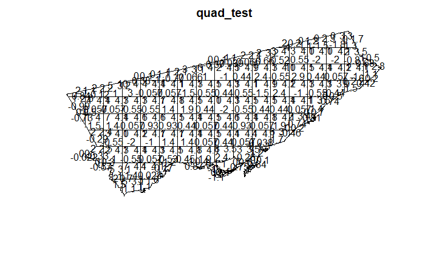

```r
plot(quad_test)
```

Save the dataset for use in the activity:

```r
save(Fast_Food, Gas_Stands, Paez_Mart, Fast_Food.ppp, Gas_Stands.ppp, Paez_Mart.ppp, Toronto, file = "Toronto Business Points.RData")
```